# MTH6139 Time Series

Coursework 1 - Apple Stock Analysis

Varunika Chellarajesh

15.03.2026

[figure not shown]

# Section 1: Prophet Forecasting for Apple Stock

## Introduction

This project applies Meta’s Prophet forecasting system to Apple stock prices.

The dataset contains daily observations of Apple stock prices (ticker symbol: AAPL), taken from Kaggle.

Events like COVID-19, global conflicts, and changes in the technology sector have had significant impacts on stock price.

The aim is to understand how the series behaves and to produce forecasts.

## Data Import

The data were imported from a CSV file stored in the `data` folder.

```r
apple_data_raw <- read.csv("data/apple.csv")
```

## Data Preparation for Prophet

The date column was converted to date format and renamed ds. The stock prices were cleaned and stored in a variable named y.

```r
apple_prophet_data <- data.frame(
  ds = as.Date(apple_data_raw$Date, format = "%m/%d/%Y"),
  y = as.numeric(gsub("[\\$,]", "", apple_data_raw$Close.Last))
)

apple_prophet_data <- na.omit(apple_prophet_data)
```

## Visualisation of the Time Series

Before fitting the model, it is useful to examine the raw time series.

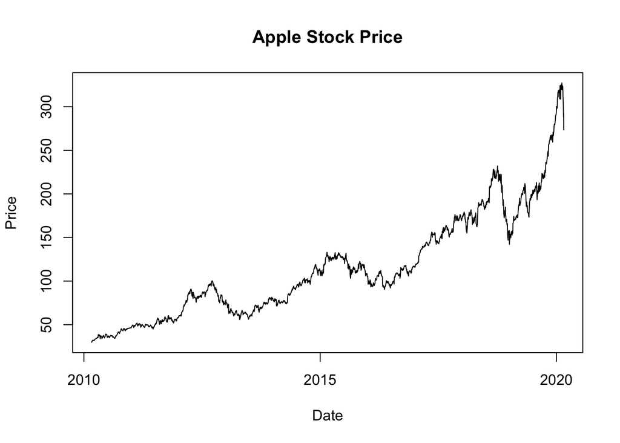

```r
plot(
  apple_prophet_data$ds,
  apple_prophet_data$y,
  type = "l",
  main = "Apple Stock Price",
  xlab = "Date",
  ylab = "Price"
)
```

The series shows a general upward trend over time, with noticeable short-term fluctuations.

## A Simple Linear Trend Check

```r
time_index <- 1:nrow(apple_prophet_data)

linear_trend_model <- lm(y ~ time_index, data = apple_prophet_data)

summary(linear_trend_model)
```

```
##
## Call:
## lm(formula = y ~ time_index, data = apple_prophet_data)
##
## Residuals:
##     Min      1Q  Median      3Q     Max
## -48.359 -15.064   1.182  11.437 116.846
##
## Coefficients:
##               Estimate Std. Error t value Pr(>|t|)
## (Intercept)  2.113e+02  9.577e-01   220.6   <2e-16 ***
## time_index  -7.662e-02  6.586e-04  -116.3   <2e-16 ***
## ---
## Signif. codes:  0 '***' 0.001 '**' 0.01 '*' 0.05 '.' 0.1 ' ' 1
##
## Residual standard error: 24.02 on 2516 degrees of freedom
## Multiple R-squared:  0.8432, Adjusted R-squared:  0.8432
## F-statistic: 1.353e+04 on 1 and 2516 DF,  p-value: < 2.2e-16
```

The output gives a summary of the overall direction of the series.

## Fitting the Prophet Model

The Prophet package was used to fit a forecasting model to the prepared Apple stock data.

```r
library(prophet)
apple_prophet_model <- prophet(apple_prophet_data)
```

```
## Disabling daily seasonality. Run prophet with daily.seasonality=TRUE to override this.
```

Prophet models the series using trend and seasonal components.

## Creating Future Dates

Future dates were generated in order to produce forecasts.

```r
apple_future_dates <- make_future_dataframe(apple_prophet_model, periods = 8)
```

## Generating Forecasts

The fitted model was used to generate forecasts.

```r
apple_forecast <- predict(apple_prophet_model, apple_future_dates)
```

## Forecast Output

It is useful to inspect some of the forecast values.

```r
tail(apple_forecast[, c("ds", "yhat", "yhat_lower", "yhat_upper")])
```

```
##              ds     yhat yhat_lower yhat_upper
## 2521 2020-03-02 253.8444   236.5455   272.4616
## 2522 2020-03-03 253.9295   234.8487   271.0845
## 2523 2020-03-04 253.6347   235.3656   272.3816
## 2524 2020-03-05 253.6144   236.6007   271.9100
## 2525 2020-03-06 253.2652   236.0691   271.4907
## 2526 2020-03-07 252.0005   234.0368   271.3483
```

The table shows predicted values together with uncertainty intervals.

## Prophet Forecast Plot

The main forecast plot is shown below.

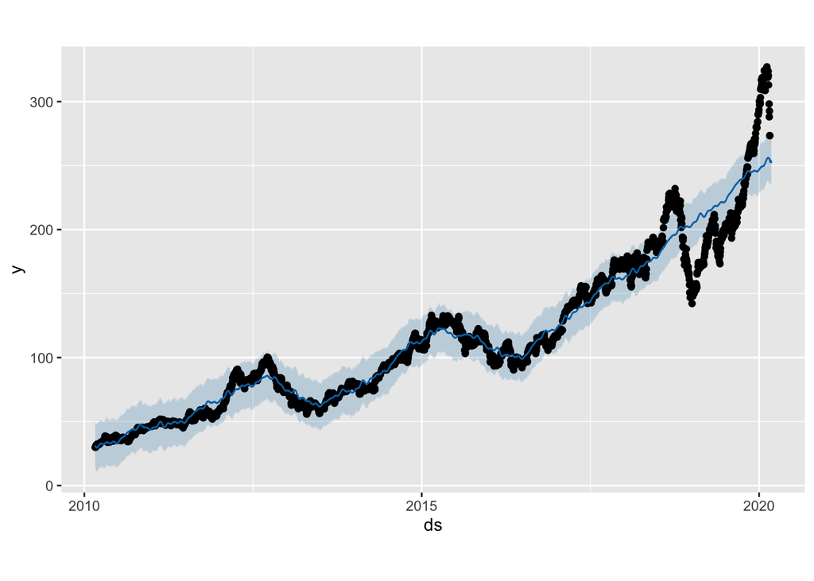

```r
plot(apple_prophet_model, apple_forecast)
```

The black points show the observed data, while the blue line shows the fitted and forecast values.

## Prophet Components

The component plots help to separate the main parts of the Prophet model.

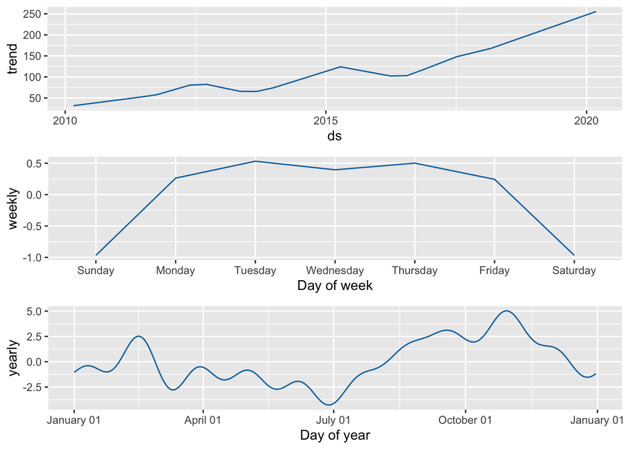

```r
prophet_plot_components(apple_prophet_model, apple_forecast)
```

These plots show how Prophet decomposes the time series.

## A Shorter Time Frame

It is useful to look at a more recent part of the data.

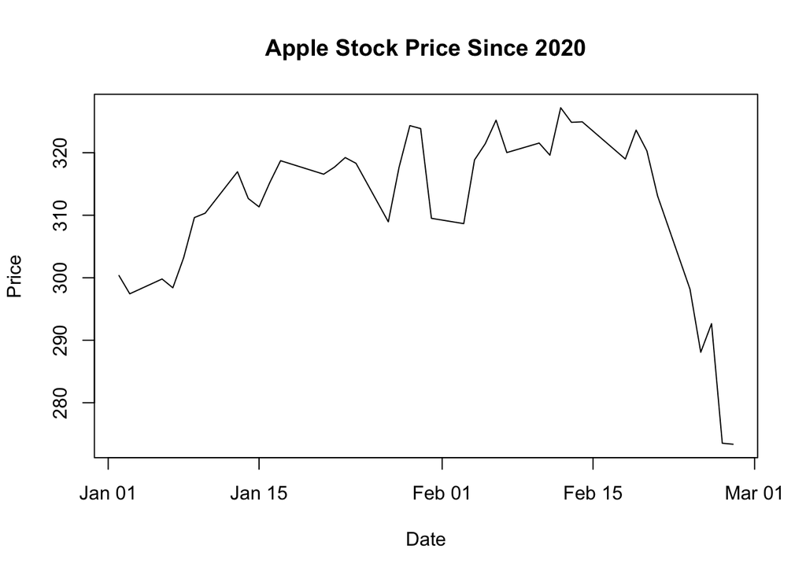

```r
recent_apple_data <- subset(
  apple_prophet_data,
  ds >= as.Date("2020-01-01")
)

plot(
  recent_apple_data$ds,
  recent_apple_data$y,
  type = "l",
  main = "Apple Stock Price Since 2020",
  xlab = "Date",
  ylab = "Price"
)
```

Looking at a shorter time frame makes it easier to observe recent movements in the series.

## Comments on the Results

Overall, Apple stock prices show a clear upward trend over time, although there are some fluctuations along the way.

There is a noticeable drop around early 2020, which is likely due to the COVID-19 pandemic, when financial markets were very uncertain.

There are also some ups and downs in the later years, which could be linked to global events and changes in the economy.

In particular, factors such as interest rates and general market conditions seem to affect the stock price at different points in time.

Overall, the stock has grown over time, but it is still influenced by many outside factors.

## Conclusion

In this report, Apple stock price data were analysed using the Prophet model.

The results show that Prophet is easy to use and produces clear visual outputs. It provides a simple way to understand trends and generate forecasts for time series data.